# Contacts with friends

# 1 Description of DataSchema variable

The description of harmonised variable is the following:

- Short name: `cont_fr`
- Variable label: `Are the contacts with friends/neighbours frequent (i.e. contact once a month or more often)`
- Variable description: `Are the contacts with friends/neighbours frequent (i.e. contact once a month or more often)`
- Domain: `Social environment`
- Value type: `categorical`
- Category coding:

| **Code** | **Category Label** |
| --- | --- |
| 0 | No |
| 1 | Yes |

- Category missings:

| **Code** | **Category Label** |
| --- | --- |
| 991 | CAPI/interviewer error |
| 992 | Impute |
| 993 | Disable to measure |
| 994 | Not attempt/not done |
| 995 | Does not answer |
| 996 | Not applicable |
| 997 | Refuse |
| 998 | Do not know |
| 999 | Missing |

# 2 Data process

## 2.1 England

### 2.1.1 Wave 1

#### 2.1.1.1 Study-specific variable description

The study-specific variable elected to be harmonised is:

- Name: `scfrd`
- Label: `do you have any friends`
- Categories:
  - `1 = Yes`
  - `2 = No`
- Missings:
  - `-9 = Not answered`
  - `-1 = Item not applicable`
- Name: `scfrdg`
- Label: `How often the respondent meets up with their friends`
- Categories:
  - `1 = Three or more times a week`
  - `2 = Once or twice a week`
  - `3 = Once or twice a month`
  - `4 = Every few months`
  - `5 = Once or twice a year`
  - `6 = Less than once a year or never`
- Missings:
  - `-9 = Not answered`
  - `-1 = Item not applicable`
- Name: `scfrdh`
- Label: `on average how often do you speak on the phone with your friends`
- Categories:
  - `1 = Three or more times a week`
  - `2 = Once or twice a week`
  - `3 = Once or twice a month`
  - `4 = Every few months`
  - `5 = Once or twice a year`
  - `6 = Less than once a year or never`
- Missings:
  - `-9 = Not answered`
  - `-1 = Item not applicable`
- Name: `scfrdi`
- Label: `on average how often do you write or email your friends`
- Categories:
  - `1 = Three or more times a week`
  - `2 = Once or twice a week`
  - `3 = Once or twice a month`
  - `4 = Every few months`
  - `5 = Once or twice a year`
  - `6 = Less than once a year or never`
- Missings:
  - `-9 = Not answered`
  - `-1 = Item not applicable`
- Description:

SCFRD

| Sample size | Missing values |
| --- | --- |
| 12099 | 1484 |

Category

|  | 1 | 2 |
| --- | --- | --- |
| Frequency | 10041.00 | 574.00 |
| Percentage | 82.99 | 4.74 |

Type of missing

|  | -1 | -9 | NA |
| --- | --- | --- | --- |
| Frequency | 1108.00 | 376.00 | 0 |
| Percentage | 9.16 | 3.11 | 0 |

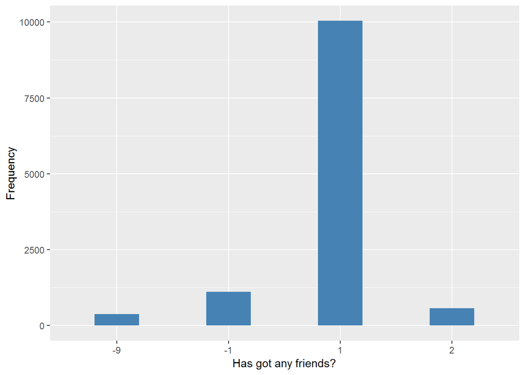

SCFRDG

| Sample size | Missing values |
| --- | --- |
| 12099 | 2263 |

Category

|  | 1 | 2 | 3 | 4 | 5 | 6 |
| --- | --- | --- | --- | --- | --- | --- |
| Frequency | 1646.0 | 4176.00 | 2434.00 | 1056.00 | 356.00 | 168.00 |
| Percentage | 13.6 | 34.52 | 20.12 | 8.73 | 2.94 | 1.39 |

Type of missing

|  | -1 | -9 | NA |
| --- | --- | --- | --- |
| Frequency | 2058.00 | 205.00 | 0 |
| Percentage | 17.01 | 1.69 | 0 |

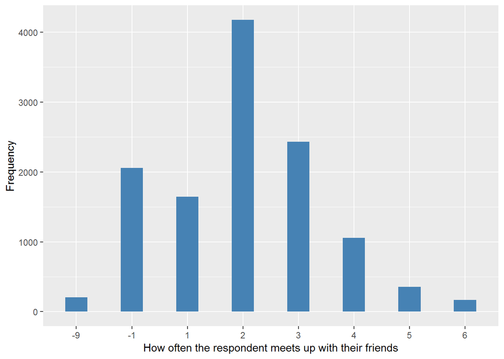

SCFRDH

| Sample size | Missing values |
| --- | --- |
| 12099 | 2333 |

Category

|  | 1 | 2 | 3 | 4 | 5 | 6 |
| --- | --- | --- | --- | --- | --- | --- |
| Frequency | 1646.0 | 4105.00 | 2513.00 | 904.00 | 283.00 | 315.0 |
| Percentage | 13.6 | 33.93 | 20.77 | 7.47 | 2.34 | 2.6 |

Type of missing

|  | -1 | -9 | NA |
| --- | --- | --- | --- |
| Frequency | 2058.00 | 275.00 | 0 |
| Percentage | 17.01 | 2.27 | 0 |

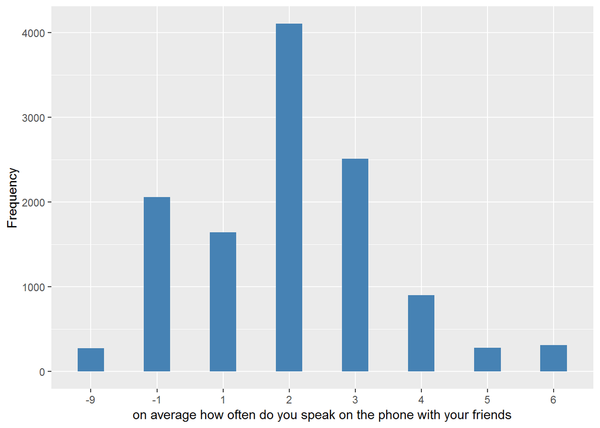

SCFRDI

| Sample size | Missing values |
| --- | --- |
| 12099 | 4443 |

Category

|  | 1 | 2 | 3 | 4 | 5 | 6 |
| --- | --- | --- | --- | --- | --- | --- |
| Frequency | 194.0 | 463.00 | 869.00 | 885.00 | 1182.00 | 4063.00 |
| Percentage | 1.6 | 3.83 | 7.18 | 7.31 | 9.77 | 33.58 |

Type of missing

|  | -1 | -9 | NA |
| --- | --- | --- | --- |
| Frequency | 2058.00 | 2385.00 | 0 |
| Percentage | 17.01 | 19.71 | 0 |

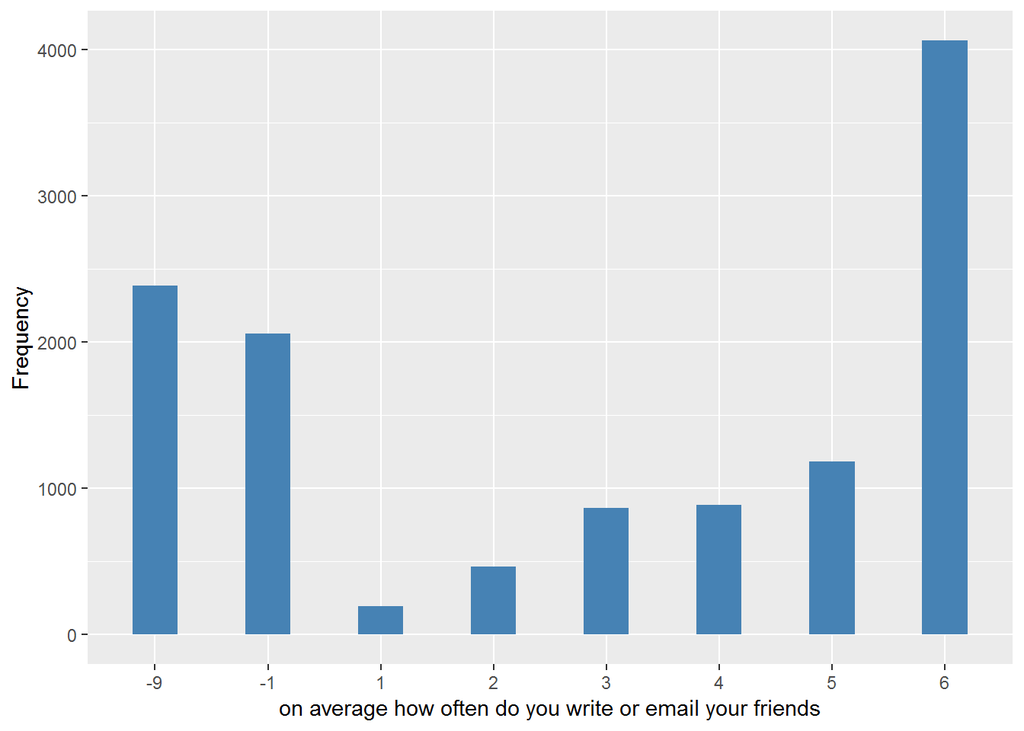

#### 2.1.1.2 Harmonisation algorithm

To compute the harmonize variable from the study-specific variable it has to be recoded as follows:

- `scfrdg in (1,2,3) OR scfrdh in (1,2,3) OR scfrdi in (1,2,3) into 1`
- `scfrdg in (4,5,6) AND scfrdh in (4,5,6) AND scfrdi in (4,5,6) into 0`
- `scfrd=2 into 0`
- `scfrdg = -9 OR scfrdh = -9 OR scfrdi = -9 into 995`
- `scfrdg = -1 OR scfrdh = -1 OR scfrdi = -1 into 996`
- `NA into 999`

**R script:**

```r
ELSA_ds_w1 <- tibble(id = ELSA_w1_cont_fr$id)

ELSA_w1_cont_fr$scfrd <- car::recode(as.vector(ELSA_w1_cont_fr$scfrd), "NA='-999'")
ELSA_w1_cont_fr$scfrdg <- car::recode(as.vector(ELSA_w1_cont_fr$scfrdg), "NA='-999'")
ELSA_w1_cont_fr$scfrdh <- car::recode(as.vector(ELSA_w1_cont_fr$scfrdh), "NA='-999'")
ELSA_w1_cont_fr$scfrdi <- car::recode(as.vector(ELSA_w1_cont_fr$scfrdi), "NA='-999'")

ELSA_ds_w1$cont_fr <- c(NA)
for (i in 1:dim(ELSA_w1_cont_fr)[1]) {
    if (ELSA_w1_cont_fr$scfrdg[i] %in% c(1, 2, 3) | ELSA_w1_cont_fr$scfrdh[i] %in%
        c(1, 2, 3) | ELSA_w1_cont_fr$scfrdi[i] %in% c(1, 2, 3)) {
        ELSA_ds_w1$cont_fr[i] = 1
    } else if (ELSA_w1_cont_fr$scfrdg[i] %in% c(4, 5, 6) & ELSA_w1_cont_fr$scfrdh[i] %in%
        c(4, 5, 6) & ELSA_w1_cont_fr$scfrdi[i] %in% c(4, 5, 6)) {
        ELSA_ds_w1$cont_fr[i] = 0
    } else if (ELSA_w1_cont_fr$scfrd[i] == 2) {
        ELSA_ds_w1$cont_fr[i] = 0
    } else if (ELSA_w1_cont_fr$scfrdg[i] == -9 | ELSA_w1_cont_fr$scfrdh[i] ==
        -9 | ELSA_w1_cont_fr$scfrdi[i] == -9) {
        ELSA_ds_w1$cont_fr[i] = 995
    } else if (ELSA_w1_cont_fr$scfrdg[i] == -1 | ELSA_w1_cont_fr$scfrdh[i] ==
        -1 | ELSA_w1_cont_fr$scfrdi[i] == -1) {
        ELSA_ds_w1$cont_fr[i] = 996
    }
}

ELSA_ds_w1$cont_fr <- car::recode(as.vector(ELSA_ds_w1$cont_fr), "NA='999'")
ELSA_ds_w1$cont_fr <- labelled(ELSA_ds_w1$cont_fr, labels = c(No = 0, Yes = 1,
    Missing = 999, `Do not know` = 998, Refuse = 997, `Not applicable` = 996,
    `Don't answer` = 995, `Not attempt/not done/not yet recorded` = 994, `Disable to measure` = 993,
    Impute = 992, `CAPI/interviewer error` = 991))
```

#### 2.1.1.3 Statistical description of the new harmonised variable

| Sample size | Missing values |
| --- | --- |
| 12099 | 1746 |

Category

|  | 0 | 1 |
| --- | --- | --- |
| Frequency | 1237.00 | 9116.00 |
| Percentage | 10.22 | 75.35 |

Type of missing

|  | 991 | 992 | 993 | 994 | 995 | 996 | 997 | 998 | 999 | NA |
| --- | --- | --- | --- | --- | --- | --- | --- | --- | --- | --- |
| Frequency | 0 | 0 | 0 | 0 | 262.00 | 1484.00 | 0 | 0 | 0 | 0 |
| Percentage | 0 | 0 | 0 | 0 | 2.17 | 12.27 | 0 | 0 | 0 | 0 |

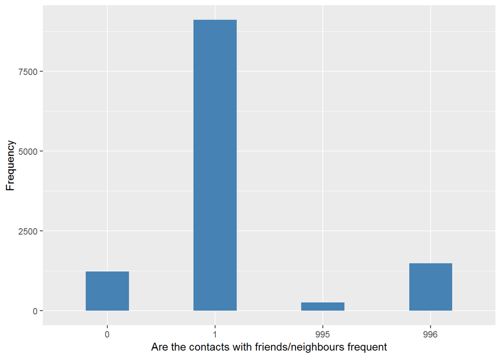

#### 2.1.1.4 Validation

### 2.1.2 Wave 2

#### 2.1.2.1 Study-specific variable description

The study-specific variable elected to be harmonised is:

- Name: `scfrd`
- Label: `do you have any friends`
- Categories:
  - `1 = Yes`
  - `2 = No`
- Missings:
  - `-9 = Not answered`
  - `-1 = Item not applicable`
- Name: `scfrdg`
- Label: `How often the respondent meets up with their friends`
- Categories:
  - `1 = Three or more times a week`
  - `2 = Once or twice a week`
  - `3 = Once or twice a month`
  - `4 = Every few months`
  - `5 = Once or twice a year`
  - `6 = Less than once a year or never`
- Missings:
  - `-9 = Not answered`
  - `-1 = Item not applicable`
- Name: `scfrdh`
- Label: `on average how often do you speak on the phone with your friends`
- Categories:
  - `1 = Three or more times a week`
  - `2 = Once or twice a week`
  - `3 = Once or twice a month`
  - `4 = Every few months`
  - `5 = Once or twice a year`
  - `6 = Less than once a year or never`
- Missings:
  - `-9 = Not answered`
  - `-1 = Item not applicable`
- Name: `scfrdi`
- Label: `on average how often do you write or email your friends`
- Categories:
  - `1 = Three or more times a week`
  - `2 = Once or twice a week`
  - `3 = Once or twice a month`
  - `4 = Every few months`
  - `5 = Once or twice a year`
  - `6 = Less than once a year or never`
- Missings:
  - `-9 = Not answered`
  - `-1 = Item not applicable`
- Description:

SCFRD

| Sample size | Missing values |
| --- | --- |
| 9432 | 1186 |

Category

|  | 1 | 2 |
| --- | --- | --- |
| Frequency | 7857.0 | 389.00 |
| Percentage | 83.3 | 4.12 |

Type of missing

|  | -1 | -9 | NA |
| --- | --- | --- | --- |
| Frequency | 1072.00 | 114.00 | 0 |
| Percentage | 11.37 | 1.21 | 0 |

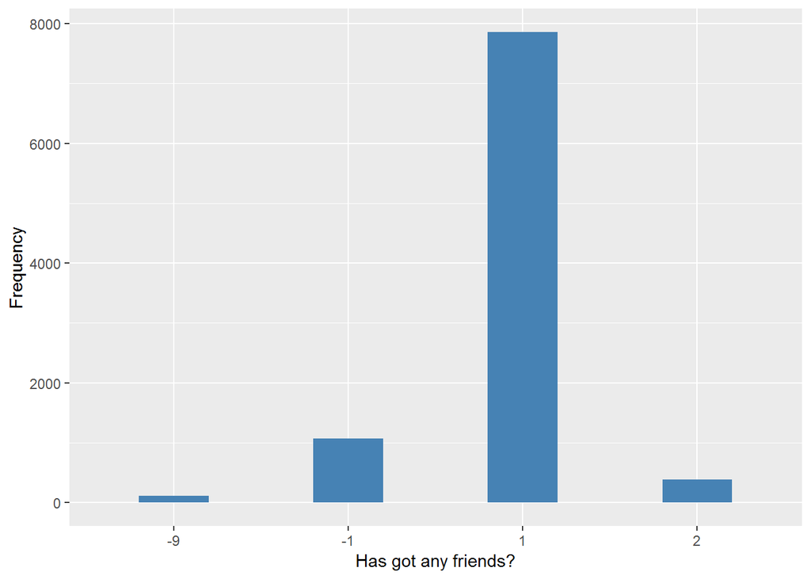

SCFRDG

| Sample size | Missing values |
| --- | --- |
| 9432 | 1712 |

Category

|  | 1 | 2 | 3 | 4 | 5 | 6 |
| --- | --- | --- | --- | --- | --- | --- |
| Frequency | 1204.00 | 3141.0 | 2077.00 | 873.00 | 283 | 142.00 |
| Percentage | 12.77 | 33.3 | 22.02 | 9.26 | 3 | 1.51 |

Type of missing

|  | -1 | -9 | NA |
| --- | --- | --- | --- |
| Frequency | 1575.0 | 137.00 | 0 |
| Percentage | 16.7 | 1.45 | 0 |

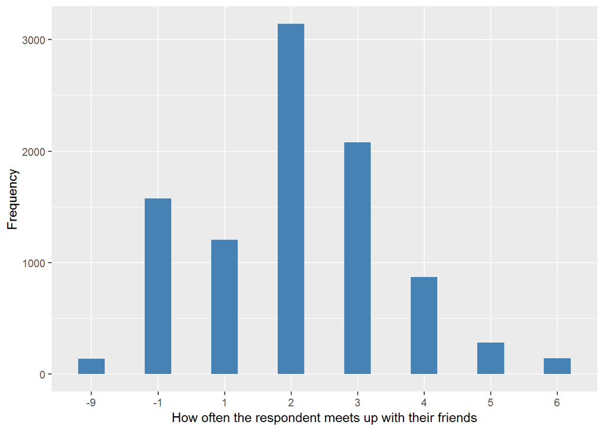

SCFRDH

| Sample size | Missing values |
| --- | --- |
| 9432 | 1713 |

Category

|  | 1 | 2 | 3 | 4 | 5 | 6 |
| --- | --- | --- | --- | --- | --- | --- |
| Frequency | 1276.00 | 3098.00 | 2147.00 | 755 | 215.00 | 228.00 |
| Percentage | 13.53 | 32.85 | 22.76 | 8 | 2.28 | 2.42 |

Type of missing

|  | -1 | -9 | NA |
| --- | --- | --- | --- |
| Frequency | 1575.0 | 138.00 | 0 |
| Percentage | 16.7 | 1.46 | 0 |

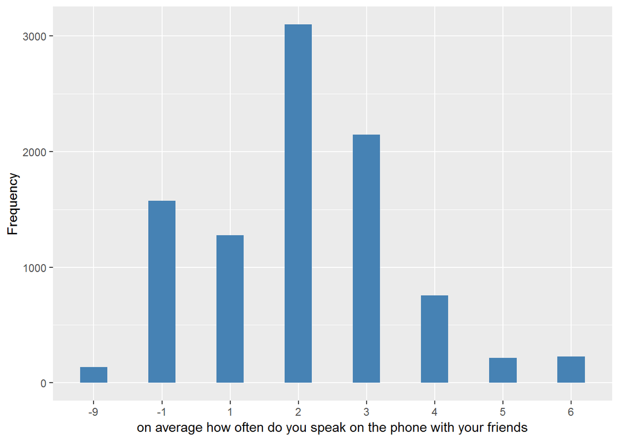

SCFRDI

| Sample size | Missing values |
| --- | --- |
| 9432 | 2842 |

Category

|  | 1 | 2 | 3 | 4 | 5 | 6 |
| --- | --- | --- | --- | --- | --- | --- |
| Frequency | 178.00 | 480.00 | 750.00 | 777.00 | 866.00 | 3539.00 |
| Percentage | 1.89 | 5.09 | 7.95 | 8.24 | 9.18 | 37.52 |

Type of missing

|  | -1 | -9 | NA |
| --- | --- | --- | --- |
| Frequency | 1575.0 | 1267.00 | 0 |
| Percentage | 16.7 | 13.43 | 0 |

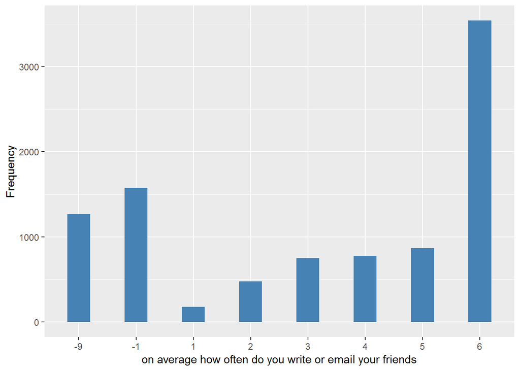

#### 2.1.2.2 Harmonisation algorithm

To recode the harmonize variable from the study-specific variable it has to be recoded as follows:

- `scfrdg in (1,2,3) OR scfrdh in (1,2,3) OR scfrdi in (1,2,3) into 1`
- `scfrdg in (4,5,6) AND scfrdh in (4,5,6) AND scfrdi in (4,5,6) into 0`
- `scfrd=2 into 0`
- `scfrdg = -9 OR scfrdh = -9 OR scfrdi = -9 into 995`
- `scfrdg = -1 OR scfrdh = -1 OR scfrdi = -1 into 996`
- `NA into 999`

**R script:**

```r
ELSA_ds_w2 <- tibble(id = ELSA_w2_cont_fr$id)

ELSA_w2_cont_fr$scfrd <- car::recode(as.vector(ELSA_w2_cont_fr$scfrd), "NA='-999'")
ELSA_w2_cont_fr$scfrdg <- car::recode(as.vector(ELSA_w2_cont_fr$scfrdg), "NA='-999'")
ELSA_w2_cont_fr$scfrdh <- car::recode(as.vector(ELSA_w2_cont_fr$scfrdh), "NA='-999'")
ELSA_w2_cont_fr$scfrdi <- car::recode(as.vector(ELSA_w2_cont_fr$scfrdi), "NA='-999'")

ELSA_ds_w2$cont_fr <- c(NA)
for (i in 1:dim(ELSA_w2_cont_fr)[1]) {
    if (ELSA_w2_cont_fr$scfrdg[i] %in% c(1, 2, 3) | ELSA_w2_cont_fr$scfrdh[i] %in%
        c(1, 2, 3) | ELSA_w2_cont_fr$scfrdi[i] %in% c(1, 2, 3)) {
        ELSA_ds_w2$cont_fr[i] = 1
    } else if (ELSA_w2_cont_fr$scfrdg[i] %in% c(4, 5, 6) & ELSA_w2_cont_fr$scfrdh[i] %in%
        c(4, 5, 6) & ELSA_w2_cont_fr$scfrdi[i] %in% c(4, 5, 6)) {
        ELSA_ds_w2$cont_fr[i] = 0
    } else if (ELSA_w2_cont_fr$scfrd[i] == 2) {
        ELSA_ds_w2$cont_fr[i] = 0
    } else if (ELSA_w2_cont_fr$scfrdg[i] == -9 | ELSA_w2_cont_fr$scfrdh[i] ==
        -9 | ELSA_w2_cont_fr$scfrdi[i] == -9) {
        ELSA_ds_w2$cont_fr[i] = 995
    } else if (ELSA_w2_cont_fr$scfrdg[i] == -1 | ELSA_w2_cont_fr$scfrdh[i] ==
        -1 | ELSA_w2_cont_fr$scfrdi[i] == -1) {
        ELSA_ds_w2$cont_fr[i] = 996
    }
}

ELSA_ds_w2$cont_fr <- car::recode(as.vector(ELSA_ds_w2$cont_fr), "NA='999'")
ELSA_ds_w2$cont_fr <- labelled(ELSA_ds_w2$cont_fr, labels = c(No = 0, Yes = 1,
    Missing = 999, `Do not know` = 998, Refuse = 997, `Not applicable` = 996,
    `Don't answer` = 995, `Not attempt/not done/not yet recorded` = 994, `Disable to measure` = 993,
    Impute = 992, `CAPI/interviewer error` = 991, `NOT APPLICABLE - HAS NOT GOT ANY FRIENDS` = 990))
```

#### 2.1.2.3 Statistical description of the new harmonised variable

| Sample size | Missing values |
| --- | --- |
| 9432 | 1320 |

Category

|  | 0 | 1 |
| --- | --- | --- |
| Frequency | 981.0 | 7131.0 |
| Percentage | 10.4 | 75.6 |

Type of missing

|  | 991 | 992 | 993 | 994 | 995 | 996 | 997 | 998 | 999 | NA |
| --- | --- | --- | --- | --- | --- | --- | --- | --- | --- | --- |
| Frequency | 0 | 0 | 0 | 0 | 134.00 | 1186.00 | 0 | 0 | 0 | 0 |
| Percentage | 0 | 0 | 0 | 0 | 1.42 | 12.57 | 0 | 0 | 0 | 0 |

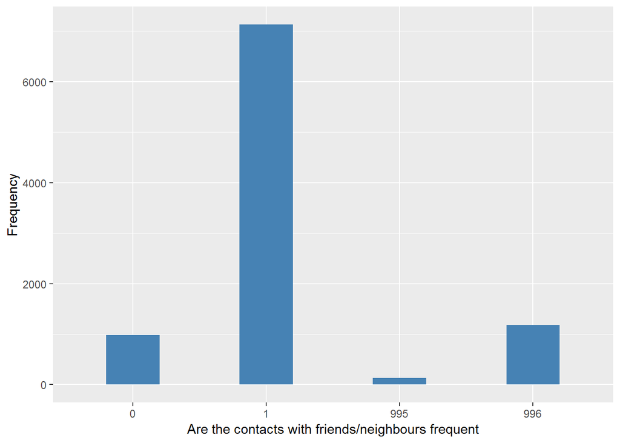

#### 2.1.2.4 Validation

### 2.1.3 Wave 3

#### 2.1.3.1 Study-specific variable description

The study-specific variable elected to be harmonised is:

- Name: `scfrd`
- Label: `do you have any friends`
- Categories:
  - `1 = Yes`
  - `2 = No`
- Missings:
  - `-9 = Not answered`
  - `-1 = Item not applicable`
- Name: `scfrdg`
- Label: `How often the respondent meets up with their friends`
- Categories:
  - `1 = Three or more times a week`
  - `2 = Once or twice a week`
  - `3 = Once or twice a month`
  - `4 = Every few months`
  - `5 = Once or twice a year`
  - `6 = Less than once a year or never`
- Missings:
  - `-9 = Not answered`
  - `-8 = Don't know`
  - `-1 = Item not applicable`
- Name: `scfrdh`
- Label: `on average how often do you speak on the phone with your friends`
- Categories:
  - `1 = Three or more times a week`
  - `2 = Once or twice a week`
  - `3 = Once or twice a month`
  - `4 = Every few months`
  - `5 = Once or twice a year`
  - `6 = Less than once a year or never`
- Missings:
  - `-9 = Not answered`
  - `-8 = Don't know`
  - `-1 = Item not applicable`
- Name: `scfrdi`
- Label: `on average how often do you write or email your friends`
- Categories:
  - `1 = Three or more times a week`
  - `2 = Once or twice a week`
  - `3 = Once or twice a month`
  - `4 = Every few months`
  - `5 = Once or twice a year`
  - `6 = Less than once a year or never`
- Missings:
  - `-9 = Not answered`
  - `-8 = Don't know`
  - `-1 = Item not applicable`
- Description:

```
## $values_table
##               -9      -1       1      2
## Frequency  107.0 1527.00 7735.00 402.00
## Percentage   1.1   15.63   79.16   4.11
##
## $n_table
##      Sample size Missing values
## [1,]        9771              0
```

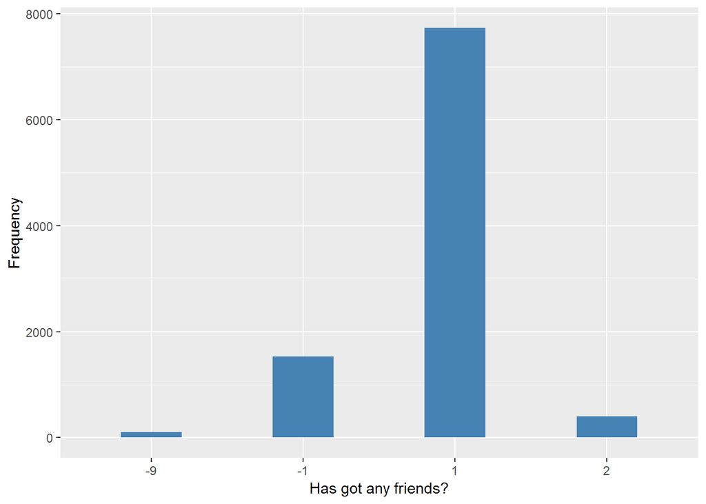

```
## $values_table
##                -9      -1       1       2       3      4      5      6
## Frequency  136.00 2036.00 1138.00 3132.00 2055.00 894.00 249.00 131.00
## Percentage   1.39   20.84   11.65   32.05   21.03   9.15   2.55   1.34
##
## $n_table
##      Sample size Missing values
## [1,]        9771              0
```

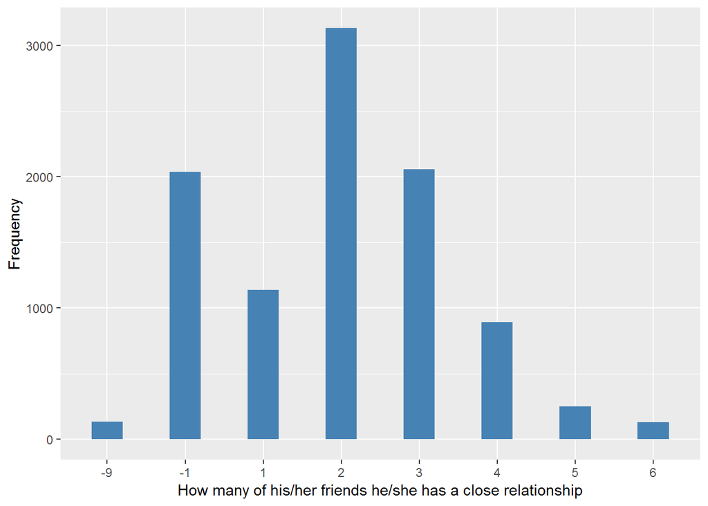

```
## $values_table
##               -9      -1       1      2       3      4      5      6
## Frequency  156.0 2036.00 1193.00 3146.0 2092.00 740.00 196.00 212.00
## Percentage   1.6   20.84   12.21   32.2   21.41   7.57   2.01   2.17
##
## $n_table
##      Sample size Missing values
## [1,]        9771              0
```

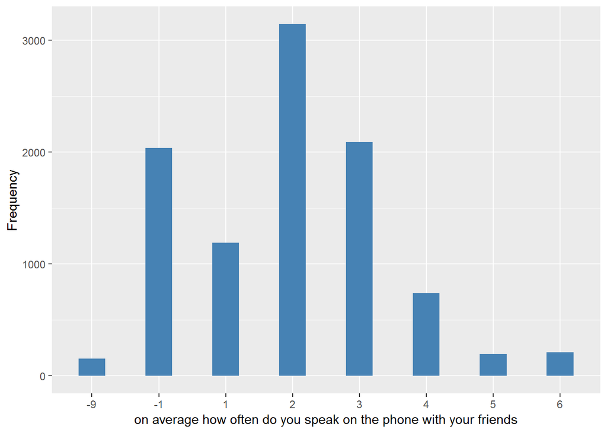

```
## $values_table
##                 -9      -1      1      2      3      4      5       6
## Frequency  1220.00 2036.00 242.00 660.00 964.00 736.00 833.00 3080.00
## Percentage   12.49   20.84   2.48   6.75   9.87   7.53   8.53   31.52
##
## $n_table
##      Sample size Missing values
## [1,]        9771              0
```

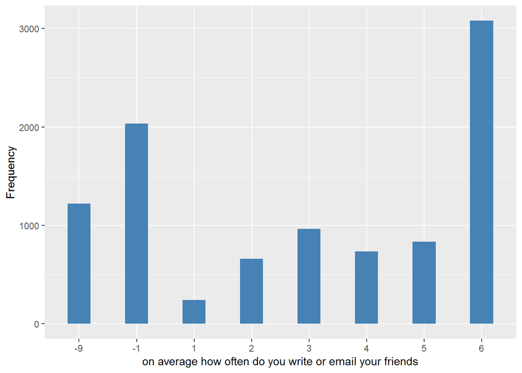

#### 2.1.3.2 Harmonisation algorithm

To recode the harmonize variable from the study-specific variable it has to be recoded as follows:

- `scfrdg in (1,2,3) OR scfrdh in (1,2,3) OR scfrdi in (1,2,3) into 1`
- `scfrdg in (4,5,6) AND scfrdh in (4,5,6) AND scfrdi in (4,5,6) into 0`
- `scfrd=2 into 0`
- `scfrdg = -9 OR scfrdh = -9 OR scfrdi = -9 into 995`
- `scfrdg = -8 OR scfrdh = -8 OR scfrdi = -8 into 998`
- `scfrdg = -1 OR scfrdh = -1 OR scfrdi = -1 into 996`
- `NA into 999`

**R script:**

```r
ELSA_ds_w3 <- tibble(id = ELSA_w3_cont_fr$id)

ELSA_w3_cont_fr$scfrd <- car::recode(as.vector(ELSA_w3_cont_fr$scfrd), "NA='-999'")
ELSA_w3_cont_fr$scfrdg <- car::recode(as.vector(ELSA_w3_cont_fr$scfrdg), "NA='-999'")
ELSA_w3_cont_fr$scfrdh <- car::recode(as.vector(ELSA_w3_cont_fr$scfrdh), "NA='-999'")
ELSA_w3_cont_fr$scfrdi <- car::recode(as.vector(ELSA_w3_cont_fr$scfrdi), "NA='-999'")

ELSA_ds_w3$cont_fr <- c(NA)
for (i in 1:dim(ELSA_w3_cont_fr)[1]) {
    if (ELSA_w3_cont_fr$scfrdg[i] %in% c(1, 2, 3) | ELSA_w3_cont_fr$scfrdh[i] %in%
        c(1, 2, 3) | ELSA_w3_cont_fr$scfrdi[i] %in% c(1, 2, 3)) {
        ELSA_ds_w3$cont_fr[i] = 1
    } else if (ELSA_w3_cont_fr$scfrdg[i] %in% c(4, 5, 6) & ELSA_w3_cont_fr$scfrdh[i] %in%
        c(4, 5, 6) & ELSA_w3_cont_fr$scfrdi[i] %in% c(4, 5, 6)) {
        ELSA_ds_w3$cont_fr[i] = 0
    } else if (ELSA_w3_cont_fr$scfrd[i] == 2) {
        ELSA_ds_w3$cont_fr[i] = 0
    } else if (ELSA_w3_cont_fr$scfrdg[i] == -9 | ELSA_w3_cont_fr$scfrdh[i] ==
        -9 | ELSA_w3_cont_fr$scfrdi[i] == -9) {
        ELSA_ds_w3$cont_fr[i] = 995
    } else if (ELSA_w3_cont_fr$scfrdg[i] == -8 | ELSA_w3_cont_fr$scfrdh[i] ==
        -8 | ELSA_w3_cont_fr$scfrdi[i] == -8) {
        ELSA_ds_w3$cont_fr[i] = 998
    } else if (ELSA_w3_cont_fr$scfrdg[i] == -1 | ELSA_w3_cont_fr$scfrdh[i] ==
        -1 | ELSA_w3_cont_fr$scfrdi[i] == -1) {
        ELSA_ds_w3$cont_fr[i] = 996
    }
}

ELSA_ds_w3$cont_fr <- car::recode(as.vector(ELSA_ds_w3$cont_fr), "NA='999'")
ELSA_ds_w3$cont_fr <- labelled(ELSA_ds_w3$cont_fr, labels = c(No = 0, Yes = 1,
    Missing = 999, `Do not know` = 998, Refuse = 997, `Not applicable` = 996,
    `Don't answer` = 995, `Not attempt/not done/not yet recorded` = 994, `Disable to measure` = 993,
    Impute = 992, `CAPI/interviewer error` = 991, `NOT APPLICABLE - HAS NOT GOT ANY FRIENDS` = 990))
```

#### 2.1.3.3 Statistical description of the new harmonised variable

| Sample size | Missing values |
| --- | --- |
| 9771 | 1773 |

Category

|  | 0 | 1 |
| --- | --- | --- |
| Frequency | 926.00 | 7072.00 |
| Percentage | 9.48 | 72.38 |

Type of missing

|  | 991 | 992 | 993 | 994 | 995 | 996 | 997 | 998 | 999 | NA |
| --- | --- | --- | --- | --- | --- | --- | --- | --- | --- | --- |
| Frequency | 0 | 0 | 0 | 0 | 139.00 | 1634.00 | 0 | 0 | 0 | 0 |
| Percentage | 0 | 0 | 0 | 0 | 1.42 | 16.72 | 0 | 0 | 0 | 0 |

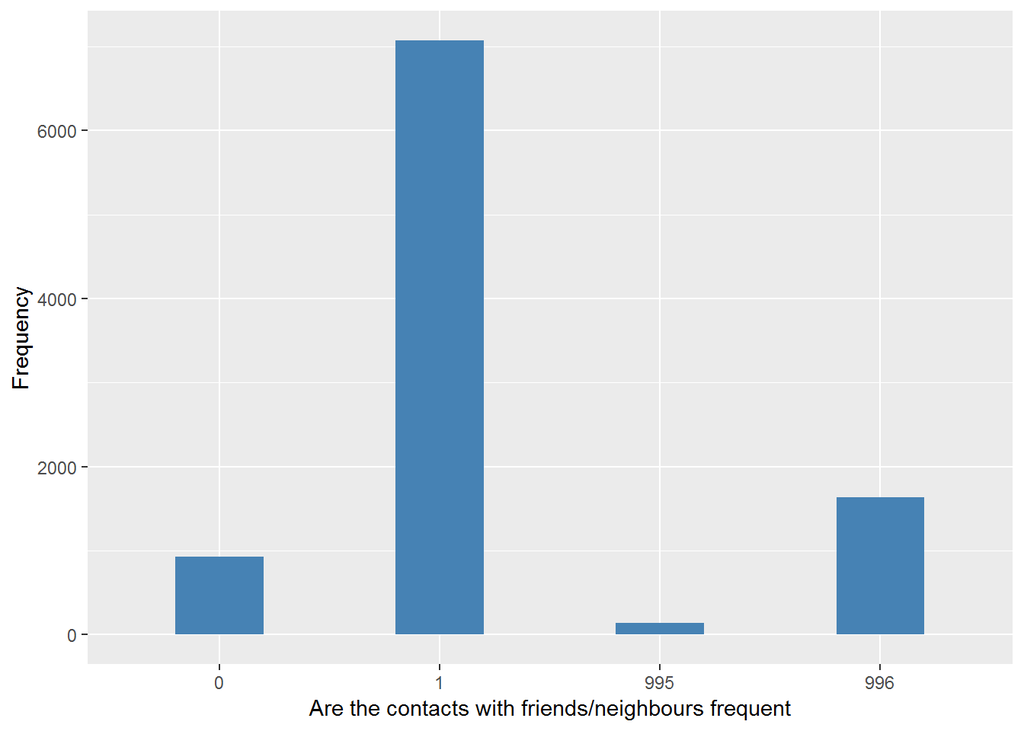

##### 2.1.3.3.1 Validation

### 2.1.4 Wave 4

#### 2.1.4.1 Study-specific variable description

The study-specific variable elected to be harmonised is:

- Name: `scfrd`
- Label: `do you have any friends`
- Categories:
  - `1 = Yes`
  - `2 = No`
- Missings:
  - `-9 = Not answered`
  - `-1 = Item not applicable`
- Name: `scfrdg`
- Label: `How often the respondent meets up with their friends`
- Categories:
  - `1 = Three or more times a week`
  - `2 = Once or twice a week`
  - `3 = Once or twice a month`
  - `4 = Every few months`
  - `5 = Once or twice a year`
  - `6 = Less than once a year or never`
- Missings:
  - `-9 = Not answered`
  - `-8 = Don't know`
  - `-1 = Item not applicable`
- Name: `scfrdh`
- Label: `on average how often do you speak on the phone with your friends`
- Categories:
  - `1 = Three or more times a week`
  - `2 = Once or twice a week`
  - `3 = Once or twice a month`
  - `4 = Every few months`
  - `5 = Once or twice a year`
  - `6 = Less than once a year or never`
- Missings:
  - `-9 = Not answered`
  - `-8 = Don't know`
  - `-1 = Item not applicable`
- Name: `scfrdi`
- Label: `on average how often do you write or email your friends`
- Categories:
  - `1 = Three or more times a week`
  - `2 = Once or twice a week`
  - `3 = Once or twice a month`
  - `4 = Every few months`
  - `5 = Once or twice a year`
  - `6 = Less than once a year or never`
- Missings:
  - `-9 = Not answered`
  - `-8 = Don't know`
  - `-1 = Item not applicable`
- Description:

```
## $values_table
##                -9      -1       1      2
## Frequency  115.00 1708.00 8756.00 471.00
## Percentage   1.04   15.46   79.24   4.26
##
## $n_table
##      Sample size Missing values
## [1,]       11050              0
```

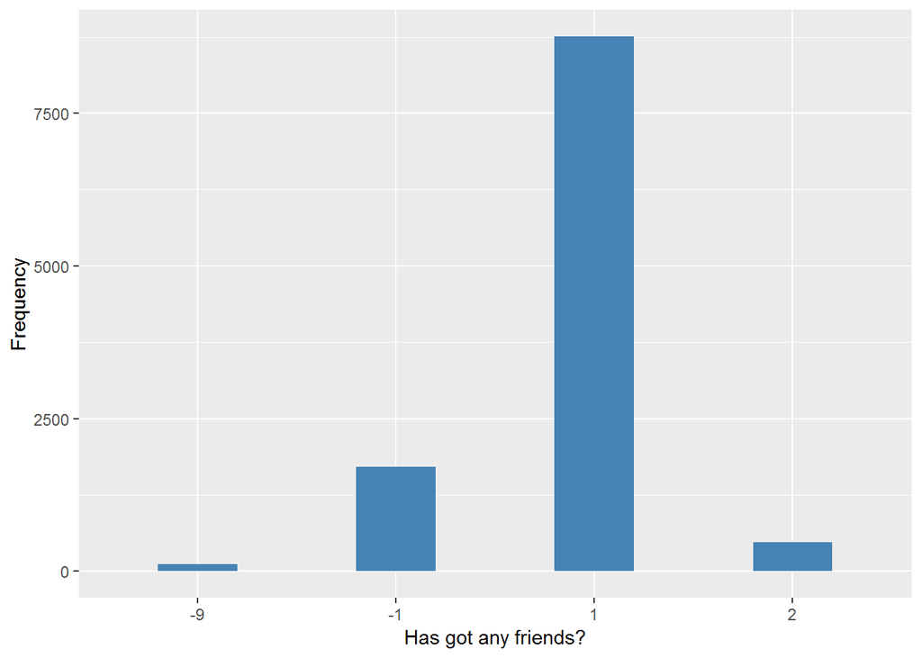

```
## $values_table
##                -9      -1       1       2       3      4      5      6
## Frequency  116.00 2294.00 1316.00 3489.00 2363.00 976.00 329.00 167.00
## Percentage   1.05   20.76   11.91   31.57   21.38   8.83   2.98   1.51
##
## $n_table
##      Sample size Missing values
## [1,]       11050              0
```

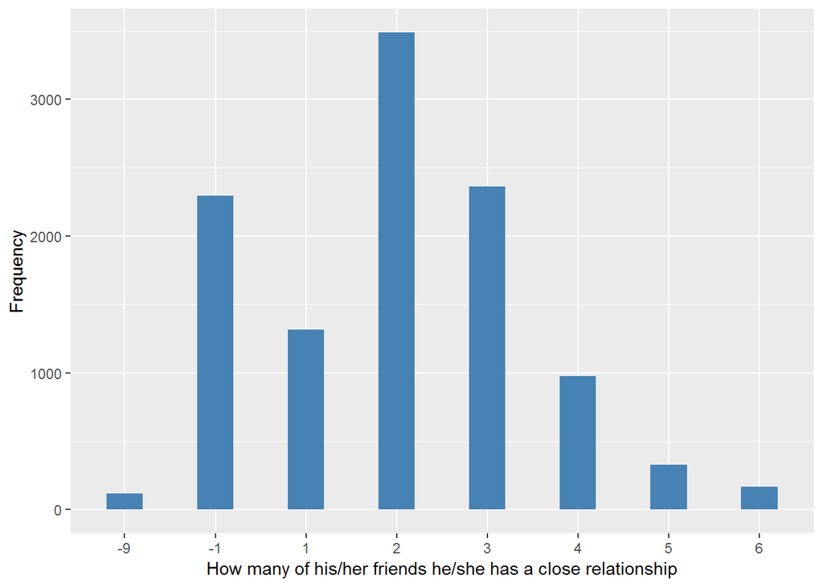

```
## $values_table
##                -9      -1       1       2       3      4      5      6
## Frequency  117.00 2294.00 1483.00 3518.00 2303.00 835.00 245.00 255.00
## Percentage   1.06   20.76   13.42   31.84   20.84   7.56   2.22   2.31
##
## $n_table
##      Sample size Missing values
## [1,]       11050              0
```

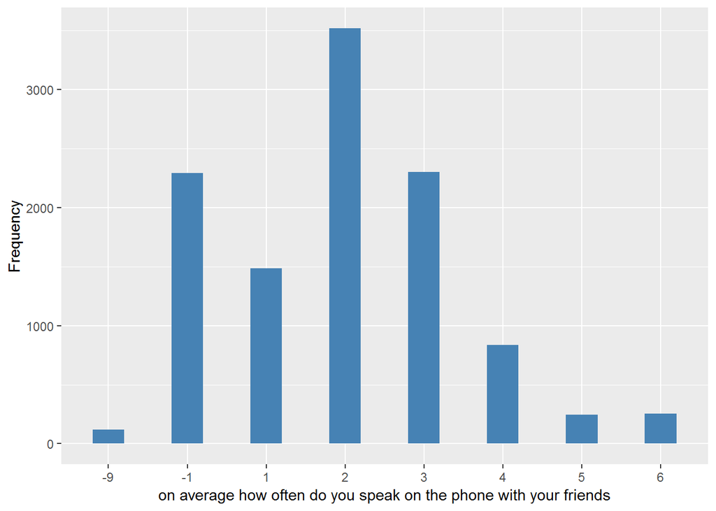

```
## $values_table
##                -9      -1      1       2       3      4      5       6
## Frequency  927.00 2294.00 411.00 1031.00 1267.00 874.00 792.00 3454.00
## Percentage   8.39   20.76   3.72    9.33   11.47   7.91   7.17   31.26
##
## $n_table
##      Sample size Missing values
## [1,]       11050              0
```

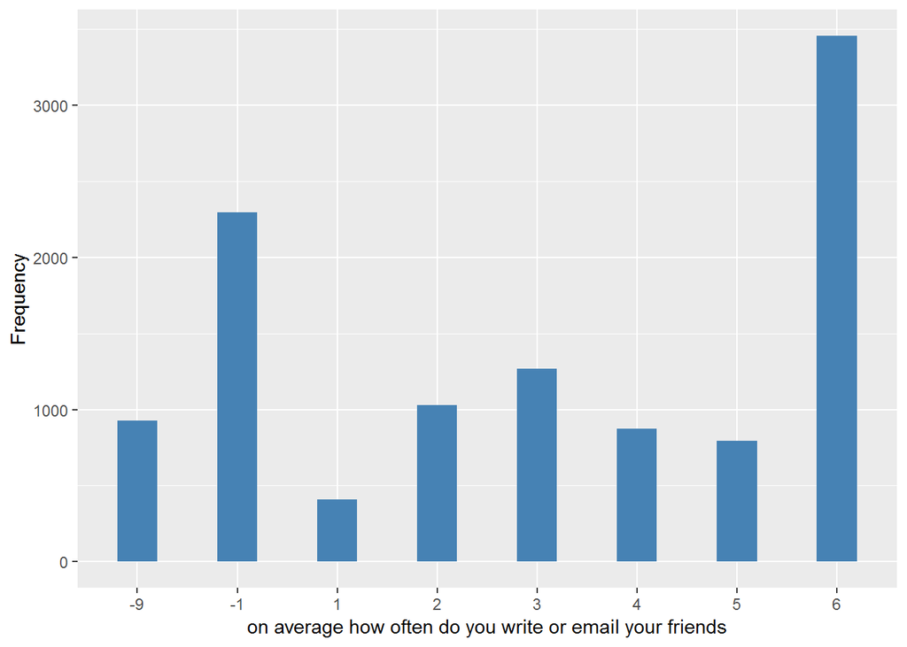

#### 2.1.4.2 Harmonisation algorithm

To recode the harmonize variable from the study-specific variable it has to be recoded as follows:

- `scfrdg in (1,2,3) OR scfrdh in (1,2,3) OR scfrdi in (1,2,3) into 1`
- `scfrdg in (4,5,6) AND scfrdh in (4,5,6) AND scfrdi in (4,5,6) into 0`
- `scfrd=2 into 0`
- `scfrdg = -9 OR scfrdh = -9 OR scfrdi = -9 into 995`
- `scfrdg = -8 OR scfrdh = -8 OR scfrdi = -8 into 998`
- `scfrdg = -1 OR scfrdh = -1 OR scfrdi = -1 into 996`
- `NA into 999`

**R script:**

```r
ELSA_ds_w4 <- tibble(id = ELSA_w4_cont_fr$id)

ELSA_w4_cont_fr$scfrd <- car::recode(as.vector(ELSA_w4_cont_fr$scfrd), "NA='-999'")
ELSA_w4_cont_fr$scfrdg <- car::recode(as.vector(ELSA_w4_cont_fr$scfrdg), "NA='-999'")
ELSA_w4_cont_fr$scfrdh <- car::recode(as.vector(ELSA_w4_cont_fr$scfrdh), "NA='-999'")
ELSA_w4_cont_fr$scfrdi <- car::recode(as.vector(ELSA_w4_cont_fr$scfrdi), "NA='-999'")

ELSA_ds_w4$cont_fr <- c(NA)
for (i in 1:dim(ELSA_w4_cont_fr)[1]) {
    if (ELSA_w4_cont_fr$scfrdg[i] %in% c(1, 2, 3) | ELSA_w4_cont_fr$scfrdh[i] %in%
        c(1, 2, 3) | ELSA_w4_cont_fr$scfrdi[i] %in% c(1, 2, 3)) {
        ELSA_ds_w4$cont_fr[i] = 1
    } else if (ELSA_w4_cont_fr$scfrdg[i] %in% c(4, 5, 6) & ELSA_w4_cont_fr$scfrdh[i] %in%
        c(4, 5, 6) & ELSA_w4_cont_fr$scfrdi[i] %in% c(4, 5, 6)) {
        ELSA_ds_w4$cont_fr[i] = 0
    } else if (ELSA_w4_cont_fr$scfrd[i] == 2) {
        ELSA_ds_w4$cont_fr[i] = 0
    } else if (ELSA_w4_cont_fr$scfrdg[i] == -9 | ELSA_w4_cont_fr$scfrdh[i] ==
        -9 | ELSA_w4_cont_fr$scfrdi[i] == -9) {
        ELSA_ds_w4$cont_fr[i] = 995
    } else if (ELSA_w4_cont_fr$scfrdg[i] == -8 | ELSA_w4_cont_fr$scfrdh[i] ==
        -8 | ELSA_w4_cont_fr$scfrdi[i] == -8) {
        ELSA_ds_w4$cont_fr[i] = 998
    } else if (ELSA_w4_cont_fr$scfrdg[i] == -1 | ELSA_w4_cont_fr$scfrdh[i] ==
        -1 | ELSA_w4_cont_fr$scfrdi[i] == -1) {
        ELSA_ds_w4$cont_fr[i] = 996
    }
}

ELSA_ds_w4$cont_fr <- car::recode(as.vector(ELSA_ds_w4$cont_fr), "NA='999'")
ELSA_ds_w4$cont_fr <- labelled(ELSA_ds_w4$cont_fr, labels = c(No = 0, Yes = 1,
    Missing = 999, `Do not know` = 998, Refuse = 997, `Not applicable` = 996,
    `Don't answer` = 995, `Not attempt/not done/not yet recorded` = 994, `Disable to measure` = 993,
    Impute = 992, `CAPI/interviewer error` = 991, `NOT APPLICABLE - HAS NOT GOT ANY FRIENDS` = 990))
```

#### 2.1.4.3 Statistical description of the new harmonised variable

| Sample size | Missing values |
| --- | --- |
| 11050 | 1944 |

Category

|  | 0 | 1 |
| --- | --- | --- |
| Frequency | 1092.00 | 8014.00 |
| Percentage | 9.88 | 72.52 |

Type of missing

|  | 991 | 992 | 993 | 994 | 995 | 996 | 997 | 998 | 999 | NA |
| --- | --- | --- | --- | --- | --- | --- | --- | --- | --- | --- |
| Frequency | 0 | 0 | 0 | 0 | 121.0 | 1823.0 | 0 | 0 | 0 | 0 |
| Percentage | 0 | 0 | 0 | 0 | 1.1 | 16.5 | 0 | 0 | 0 | 0 |

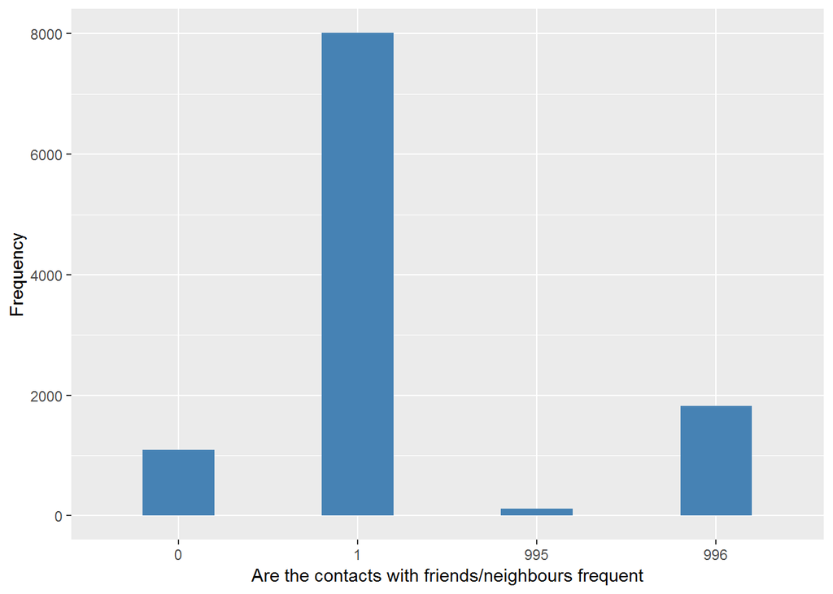

##### 2.1.4.3.1 Validation

### 2.1.5 Wave 5

#### 2.1.5.1 Study-specific variable description

The study-specific variable elected to be harmonised is:

- Name: `scfrd`
- Label: `do you have any friends`
- Categories:
  - `1 = Yes`
  - `2 = No`
- Missings:
  - `-9 = Not answered`
  - `-1 = Item not applicable`
- Name: `scfrdg`
- Label: `How often the respondent meets up with their friends`
- Categories:
  - `1 = Three or more times a week`
  - `2 = Once or twice a week`
  - `3 = Once or twice a month`
  - `4 = Every few months`
  - `5 = Once or twice a year`
  - `6 = Less than once a year or never`
- Missings:
  - `-9 = Not answered`
  - `-8 = Don't know`
  - `-2 = Schedule not applicable`
  - `-1 = Item not applicable`
- Name: `scfrdh`
- Label: `on average how often do you speak on the phone with your friends`
- Categories:
  - `1 = Three or more times a week`
  - `2 = Once or twice a week`
  - `3 = Once or twice a month`
  - `4 = Every few months`
  - `5 = Once or twice a year`
  - `6 = Less than once a year or never`
- Missings:
  - `-9 = Not answered`
  - `-8 = Don't know`
  - `-2 = Schedule not applicable`
  - `-1 = Item not applicable`
- Name: `scfrdi`
- Label: `on average how often do you write or email your friends`
- Categories:
  - `1 = Three or more times a week`
  - `2 = Once or twice a week`
  - `3 = Once or twice a month`
  - `4 = Every few months`
  - `5 = Once or twice a year`
  - `6 = Less than once a year or never`
- Missings:
  - `-9 = Not answered`
  - `-8 = Don't know`
  - `-2 = Schedule not applicable`
  - `-1 = Item not applicable`
- Description:

```
## $values_table
##                -9      -2       1      2
## Frequency  116.00 1244.00 8382.00 532.00
## Percentage   1.13   12.11   81.58   5.18
##
## $n_table
##      Sample size Missing values
## [1,]       10274              0
```

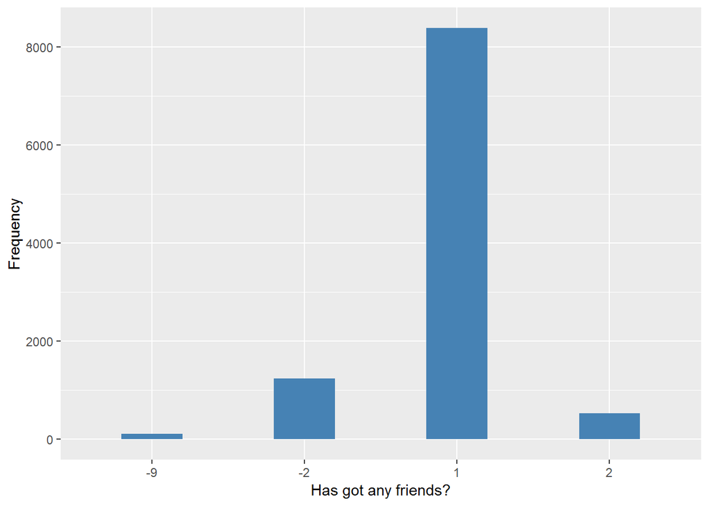

```
## $values_table
##                -9      -2     -1       1       2       3      4      5
## Frequency  117.00 1244.00 648.00 1236.00 3378.00 2196.00 979.00 323.00
## Percentage   1.14   12.11   6.31   12.03   32.88   21.37   9.53   3.14
##                 6
## Frequency  153.00
## Percentage   1.49
##
## $n_table
##      Sample size Missing values
## [1,]       10274              0
```

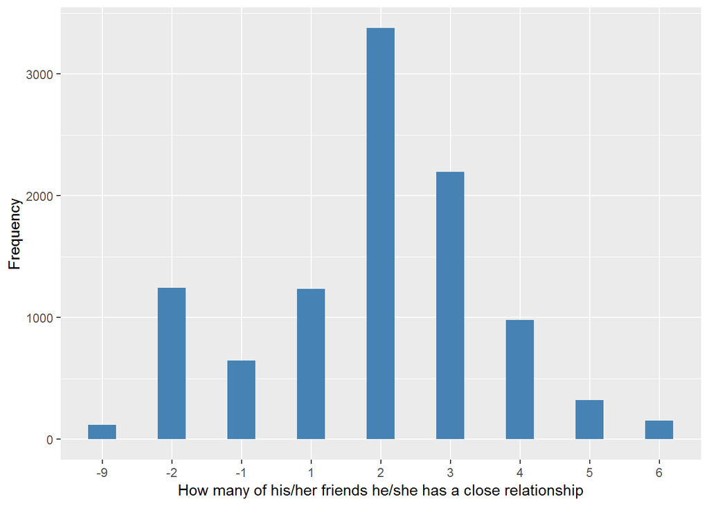

```
## $values_table
##                -9      -2     -1      1       2       3      4      5
## Frequency  120.00 1244.00 648.00 1377.0 3376.00 2297.00 766.00 212.00
## Percentage   1.17   12.11   6.31   13.4   32.86   22.36   7.46   2.06
##                 6
## Frequency  234.00
## Percentage   2.28
##
## $n_table
##      Sample size Missing values
## [1,]       10274              0
```

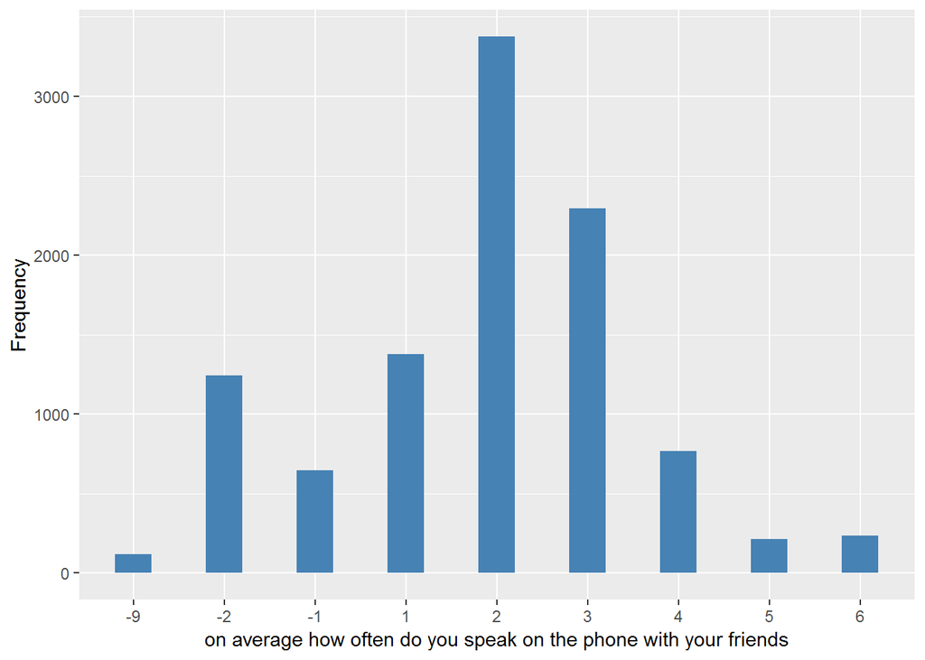

```
## $values_table
##                -9      -2     -1      1       2      3     4      5
## Frequency  890.00 1244.00 648.00 479.00 1104.00 1315.0 791.0 716.00
## Percentage   8.66   12.11   6.31   4.66   10.75   12.8   7.7   6.97
##                  6
## Frequency  3087.00
## Percentage   30.05
##
## $n_table
##      Sample size Missing values
## [1,]       10274              0
```

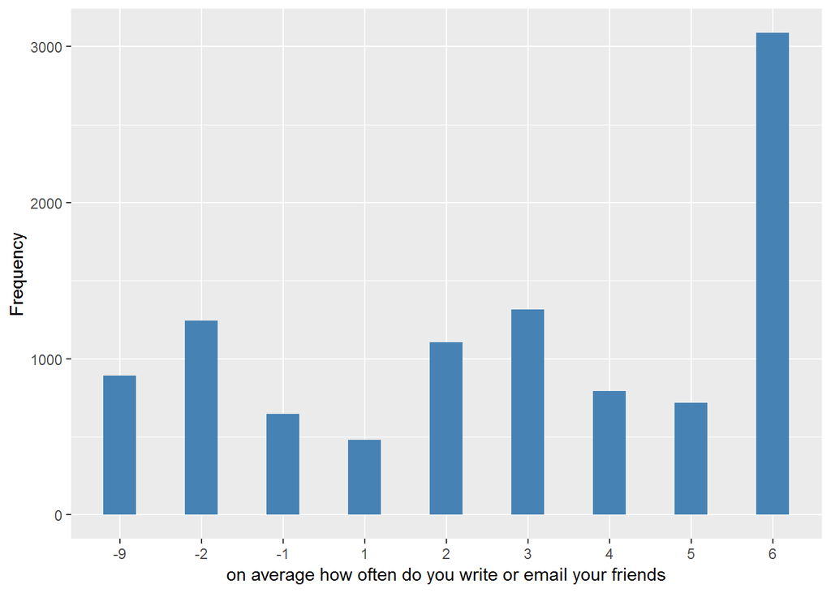

#### 2.1.5.2 Harmonisation algorithm

**R script:**

```r
ELSA_ds_w5 <- tibble(id = ELSA_w5_cont_fr$id)

ELSA_w5_cont_fr$scfrd <- car::recode(as.vector(ELSA_w5_cont_fr$scfrd), "NA='-999'")
ELSA_w5_cont_fr$scfrdg <- car::recode(as.vector(ELSA_w5_cont_fr$scfrdg), "NA='-999'")
ELSA_w5_cont_fr$scfrdh <- car::recode(as.vector(ELSA_w5_cont_fr$scfrdh), "NA='-999'")
ELSA_w5_cont_fr$scfrdi <- car::recode(as.vector(ELSA_w5_cont_fr$scfrdi), "NA='-999'")

ELSA_ds_w5$cont_fr <- c(NA)
for (i in 1:dim(ELSA_w5_cont_fr)[1]) {
    if (ELSA_w5_cont_fr$scfrdg[i] %in% c(1, 2, 3) | ELSA_w5_cont_fr$scfrdh[i] %in%
        c(1, 2, 3) | ELSA_w5_cont_fr$scfrdi[i] %in% c(1, 2, 3)) {
        ELSA_ds_w5$cont_fr[i] = 1
    } else if (ELSA_w5_cont_fr$scfrdg[i] %in% c(4, 5, 6) & ELSA_w5_cont_fr$scfrdh[i] %in%
        c(4, 5, 6) & ELSA_w5_cont_fr$scfrdi[i] %in% c(4, 5, 6)) {
        ELSA_ds_w5$cont_fr[i] = 0
    } else if (ELSA_w5_cont_fr$scfrd[i] == 2) {
        ELSA_ds_w5$cont_fr[i] = 0
    } else if (ELSA_w5_cont_fr$scfrdg[i] == -9 | ELSA_w5_cont_fr$scfrdh[i] ==
        -9 | ELSA_w5_cont_fr$scfrdi[i] == -9) {
        ELSA_ds_w5$cont_fr[i] = 995
    } else if (ELSA_w5_cont_fr$scfrdg[i] == -8 | ELSA_w5_cont_fr$scfrdh[i] ==
        -8 | ELSA_w5_cont_fr$scfrdi[i] == -8) {
        ELSA_ds_w5$cont_fr[i] = 998
    } else if (ELSA_w5_cont_fr$scfrdg[i] %in% c(-1, -2) | ELSA_w5_cont_fr$scfrdh[i] %in%
        c(-1, -2) | ELSA_w5_cont_fr$scfrdi[i] %in% c(-1, -2)) {
        ELSA_ds_w5$cont_fr[i] = 996
    }
}

ELSA_ds_w5$cont_fr <- car::recode(as.vector(ELSA_ds_w5$cont_fr), "NA='999'")
ELSA_ds_w5$cont_fr <- labelled(ELSA_ds_w5$cont_fr, labels = c(No = 0, Yes = 1,
    Missing = 999, `Do not know` = 998, Refuse = 997, `Not applicable` = 996,
    `Don't answer` = 995, `Not attempt/not done/not yet recorded` = 994, `Disable to measure` = 993,
    Impute = 992, `CAPI/interviewer error` = 991, `NOT APPLICABLE - HAS NOT GOT ANY FRIENDS` = 990))
```

#### 2.1.5.3 Statistical description of the new harmonised variable

| Sample size | Missing values |
| --- | --- |
| 10274 | 1488 |

Category

|  | 0 | 1 |
| --- | --- | --- |
| Frequency | 1124.00 | 7662.00 |
| Percentage | 10.94 | 74.58 |

Type of missing

|  | 991 | 992 | 993 | 994 | 995 | 996 | 997 | 998 | 999 | NA |
| --- | --- | --- | --- | --- | --- | --- | --- | --- | --- | --- |
| Frequency | 0 | 0 | 0 | 0 | 128.00 | 1360.00 | 0 | 0 | 0 | 0 |
| Percentage | 0 | 0 | 0 | 0 | 1.25 | 13.24 | 0 | 0 | 0 | 0 |

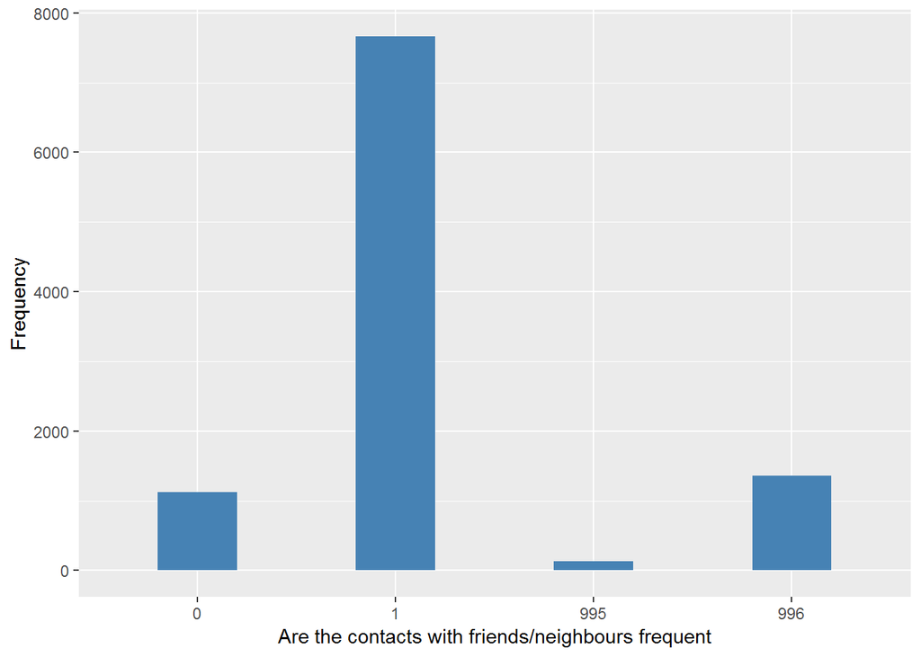

##### 2.1.5.3.1 Validation

### 2.1.6 Wave 6

#### 2.1.6.1 Study-specific variable description

The study-specific variable elected to be harmonised is:

- Name: `scfrd`
- Label: `do you have any friends`
- Categories:
  - `1 = Yes`
  - `2 = No`
- Missings:
  - `-9 = Not answered`
  - `-1 = Item not applicable`
- Name: `scfrdg`
- Label: `How often the respondent meets up with their friends`
- Categories:
  - `1 = Three or more times a week`
  - `2 = Once or twice a week`
  - `3 = Once or twice a month`
  - `4 = Every few months`
  - `5 = Once or twice a year`
  - `6 = Less than once a year or never`
- Missings:
  - `-9 = Not answered`
  - `-8 = Don't know`
  - `-2 = Schedule not applicable`
  - `-1 = Item not applicable`
- Name: `scfrdh`
- Label: `on average how often do you speak on the phone with your friends`
- Categories:
  - `1 = Three or more times a week`
  - `2 = Once or twice a week`
  - `3 = Once or twice a month`
  - `4 = Every few months`
  - `5 = Once or twice a year`
  - `6 = Less than once a year or never`
- Missings:
  - `-9 = Not answered`
  - `-8 = Don't know`
  - `-2 = Schedule not applicable`
  - `-1 = Item not applicable`
- Name: `scfrdi`
- Label: `on average how often do you write or email your friends`
- Categories:
  - `1 = Three or more times a week`
  - `2 = Once or twice a week`
  - `3 = Once or twice a month`
  - `4 = Every few months`
  - `5 = Once or twice a year`
  - `6 = Less than once a year or never`
- Missings:
  - `-9 = Not answered`
  - `-8 = Don't know`
  - `-2 = Schedule not applicable`
  - `-1 = Item not applicable`
- Name: `scfrdt`
- Label: `How often the respondent sends or receives text messsages to/from their friends`
- Categories:
  - `1 = Three or more times a week`
  - `2 = Once or twice a week`
  - `3 = Once or twice a month`
  - `4 = Every few months`
  - `5 = Once or twice a year`
  - `6 = Less than once a year or never`
- Missings:
  - `-9 = Not answered`
  - `-8 = Don't know`
  - `-2 = Schedule not applicable`
  - `-1 = Item not applicable`
- Description:

```
## $values_table
##               -9      -2       1     2
## Frequency  52.00 1604.00 8383.00 562.0
## Percentage  0.49   15.13   79.08   5.3
##
## $n_table
##      Sample size Missing values
## [1,]       10601              0
```

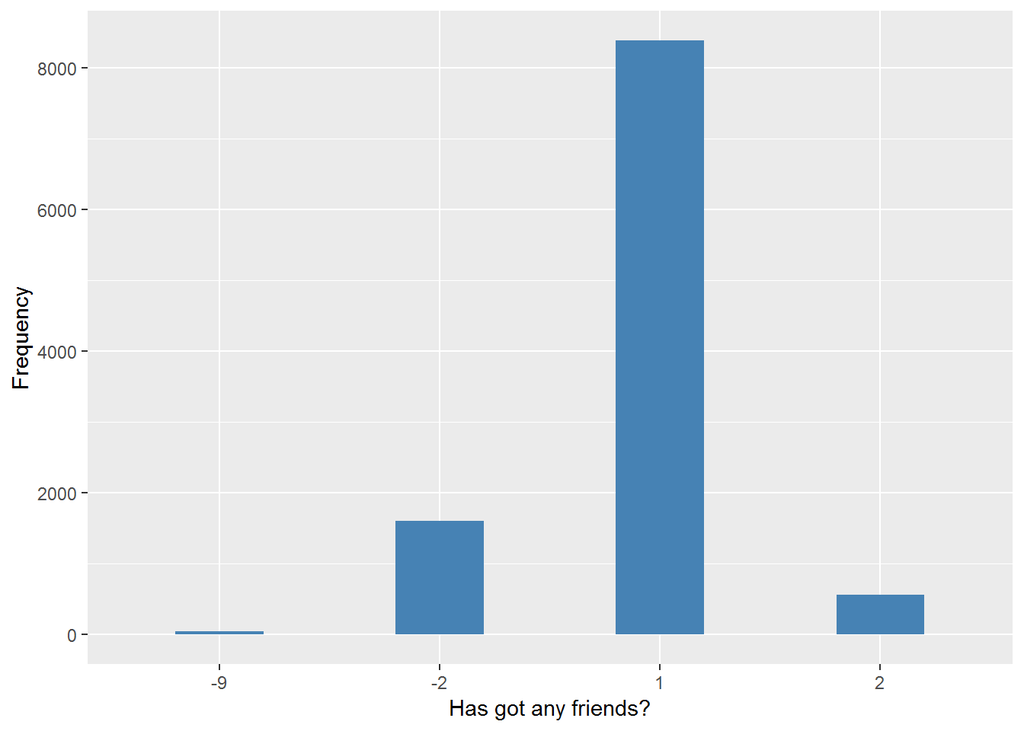

```
## $values_table
##                -9      -2     -1       1       2       3     4      5
## Frequency  123.00 1604.00 614.00 1174.00 3290.00 2296.00 997.0 328.00
## Percentage   1.16   15.13   5.79   11.07   31.03   21.66   9.4   3.09
##                 6
## Frequency  175.00
## Percentage   1.65
##
## $n_table
##      Sample size Missing values
## [1,]       10601              0
```

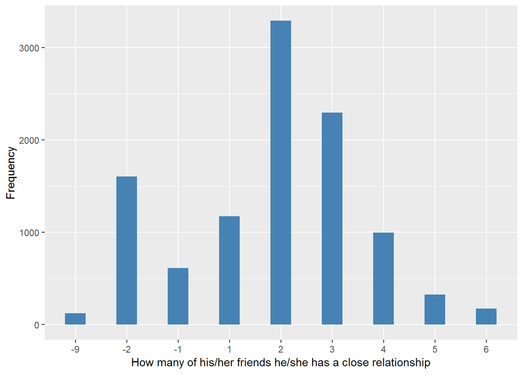

```
## $values_table
##                -9      -2     -1    1       2       3      4      5      6
## Frequency  164.00 1604.00 614.00 1272 3141.00 2400.00 888.00 268.00 250.00
## Percentage   1.55   15.13   5.79   12   29.63   22.64   8.38   2.53   2.36
##
## $n_table
##      Sample size Missing values
## [1,]       10601              0
```

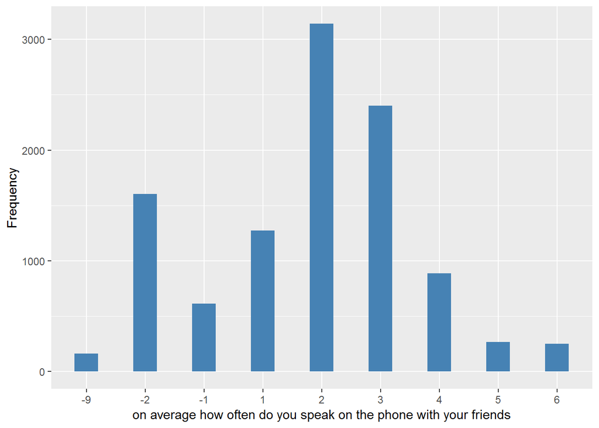

```
## $values_table
##                -9      -2     -1   1       2       3      4      5       6
## Frequency  940.00 1604.00 614.00 424 1074.00 1333.00 832.00 576.00 3204.00
## Percentage   8.87   15.13   5.79   4   10.13   12.57   7.85   5.43   30.22
##
## $n_table
##      Sample size Missing values
## [1,]       10601              0
```

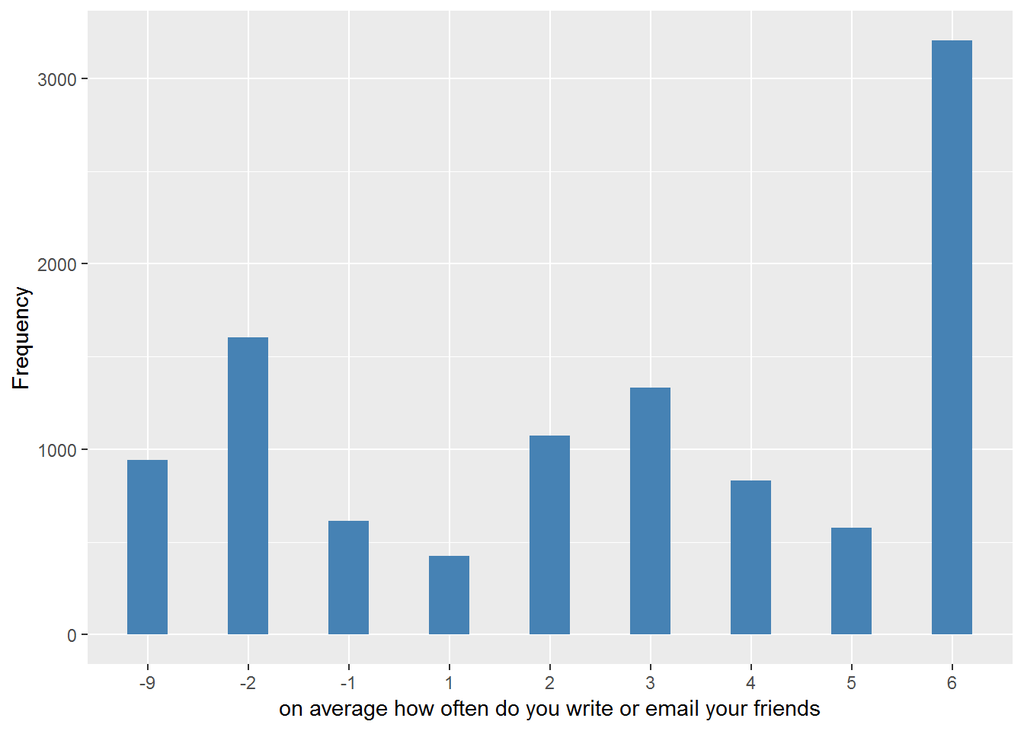

```
## $values_table
##                -9      -2     -1      1       2       3      4      5
## Frequency  791.00 1604.00 614.00 990.00 1468.00 1308.00 542.00 281.00
## Percentage   7.46   15.13   5.79   9.34   13.85   12.34   5.11   2.65
##                  6
## Frequency  3003.00
## Percentage   28.33
##
## $n_table
##      Sample size Missing values
## [1,]       10601              0
```

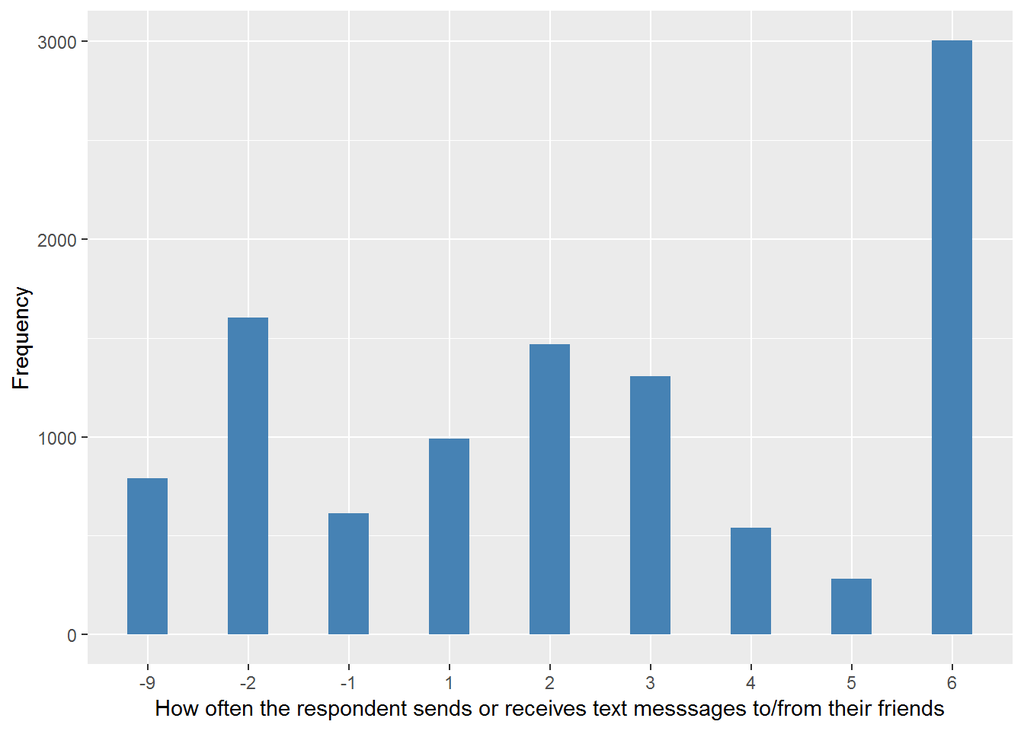

#### 2.1.6.2 Harmonisation algorithm

To recode the harmonize variable from the study-specific variable it has to be recoded as follows:

- `scfrdg in (1,2,3) OR scfrdh in (1,2,3) OR scfrdi in (1,2,3) OR scfrdt in (1,2,3) into 1`
- `scfrdg in (4,5,6) AND scfrdh in (4,5,6) AND scfrdi in (4,5,6) AND scfrdt in (4,5,6) into 0`
- `scfrd=2 into 0`
- `scfrdg = -9 OR scfrdh = -9 OR scfrdi = -9 OR scfrdt = -9 into 995`
- `scfrdg = -8 OR scfrdh = -8 OR scfrdi = -8 OR scfrdt = -8 into 998`
- `scfrdg in (-1, -2) OR scfrdh in (-1, -2) OR scfrdi in (-1, -2) OR scfrdt in (-1, -2) into 996`
- `NA into 999`

**R script:**

```r
ELSA_ds_w6 <- tibble(id = ELSA_w6_cont_fr$id)

ELSA_w6_cont_fr$scfrd <- car::recode(as.vector(ELSA_w6_cont_fr$scfrd), "NA='-999'")
ELSA_w6_cont_fr$scfrdg <- car::recode(as.vector(ELSA_w6_cont_fr$scfrdg), "NA='-999'")
ELSA_w6_cont_fr$scfrdh <- car::recode(as.vector(ELSA_w6_cont_fr$scfrdh), "NA='-999'")
ELSA_w6_cont_fr$scfrdi <- car::recode(as.vector(ELSA_w6_cont_fr$scfrdi), "NA='-999'")
ELSA_w6_cont_fr$scfrdt <- car::recode(as.vector(ELSA_w6_cont_fr$scfrdt), "NA='-999'")

ELSA_ds_w6$cont_fr <- c(NA)
for (i in 1:dim(ELSA_w6_cont_fr)[1]) {
    if (ELSA_w6_cont_fr$scfrdg[i] %in% c(1, 2, 3) | ELSA_w6_cont_fr$scfrdh[i] %in%
        c(1, 2, 3) | ELSA_w6_cont_fr$scfrdi[i] %in% c(1, 2, 3) | ELSA_w6_cont_fr$scfrdt[i] %in%
        c(1, 2, 3)) {
        ELSA_ds_w6$cont_fr[i] = 1
    } else if (ELSA_w6_cont_fr$scfrdg[i] %in% c(4, 5, 6) & ELSA_w6_cont_fr$scfrdh[i] %in%
        c(4, 5, 6) & ELSA_w6_cont_fr$scfrdi[i] %in% c(4, 5, 6) & ELSA_w6_cont_fr$scfrdt[i] %in%
        c(4, 5, 6)) {
        ELSA_ds_w6$cont_fr[i] = 0
    } else if (ELSA_w6_cont_fr$scfrd[i] == 2) {
        ELSA_ds_w6$cont_fr[i] = 0
    } else if (ELSA_w6_cont_fr$scfrdg[i] == -9 | ELSA_w6_cont_fr$scfrdh[i] ==
        -9 | ELSA_w6_cont_fr$scfrdi[i] == -9 | ELSA_w6_cont_fr$scfrdt[i] ==
        -9) {
        ELSA_ds_w6$cont_fr[i] = 995
    } else if (ELSA_w6_cont_fr$scfrdg[i] == -8 | ELSA_w6_cont_fr$scfrdh[i] ==
        -8 | ELSA_w6_cont_fr$scfrdi[i] == -8 | ELSA_w6_cont_fr$scfrdt[i] ==
        -8) {
        ELSA_ds_w6$cont_fr[i] = 998
    } else if (ELSA_w6_cont_fr$scfrdg[i] %in% c(-1, -2) | ELSA_w6_cont_fr$scfrdh[i] %in%
        c(-1, -2) | ELSA_w6_cont_fr$scfrdi[i] %in% c(-1, -2) | ELSA_w6_cont_fr$scfrdt[i] %in%
        c(-1, -2)) {
        ELSA_ds_w6$cont_fr[i] = 996
    }
}

ELSA_ds_w6$cont_fr <- car::recode(as.vector(ELSA_ds_w6$cont_fr), "NA='999'")
ELSA_ds_w6$cont_fr <- labelled(ELSA_ds_w6$cont_fr, labels = c(No = 0, Yes = 1,
    Missing = 999, `Do not know` = 998, Refuse = 997, `Not applicable` = 996,
    `Don't answer` = 995, `Not attempt/not done/not yet recorded` = 994, `Disable to measure` = 993,
    Impute = 992, `CAPI/interviewer error` = 991, `NOT APPLICABLE - HAS NOT GOT ANY FRIENDS` = 990))
```

#### 2.1.6.3 Statistical description of the new harmonised variable

| Sample size | Missing values |
| --- | --- |
| 10601 | 1794 |

Category

|  | 0 | 1 |
| --- | --- | --- |
| Frequency | 1147.00 | 7660.00 |
| Percentage | 10.82 | 72.26 |

Type of missing

|  | 991 | 992 | 993 | 994 | 995 | 996 | 997 | 998 | 999 | NA |
| --- | --- | --- | --- | --- | --- | --- | --- | --- | --- | --- |
| Frequency | 0 | 0 | 0 | 0 | 138.0 | 1656.00 | 0 | 0 | 0 | 0 |
| Percentage | 0 | 0 | 0 | 0 | 1.3 | 15.62 | 0 | 0 | 0 | 0 |

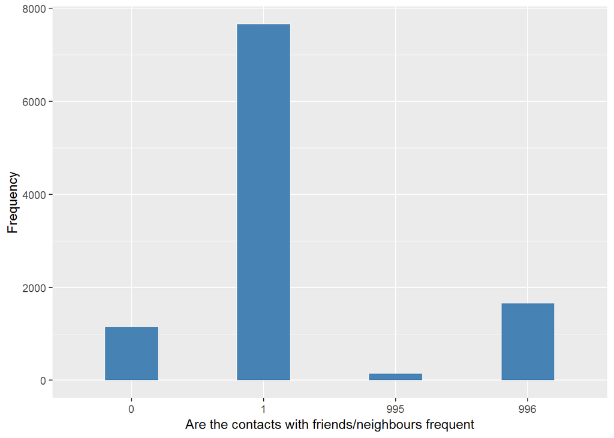

##### 2.1.6.3.1 Validation

### 2.1.7 Wave 7

#### 2.1.7.1 Study-specific variable description

The study-specific variable elected to be harmonised is:

- Name: `scfrd`
- Label: `do you have any friends`
- Categories:
  - `1 = Yes`
  - `2 = No`
- Missings:
  - `-9 = Not answered`
  - `-1 = Item not applicable`
- Name: `scfrdg`
- Label: `How often the respondent meets up with their friends`
- Categories:
  - `1 = Three or more times a week`
  - `2 = Once or twice a week`
  - `3 = Once or twice a month`
  - `4 = Every few months`
  - `5 = Once or twice a year`
  - `6 = Less than once a year or never`
- Missings:
  - `-9 = Not answered`
  - `-8 = Don't know`
  - `-2 = Schedule not applicable`
  - `-1 = Item not applicable`
- Name: `scfrdh`
- Label: `on average how often do you speak on the phone with your friends`
- Categories:
  - `1 = Three or more times a week`
  - `2 = Once or twice a week`
  - `3 = Once or twice a month`
  - `4 = Every few months`
  - `5 = Once or twice a year`
  - `6 = Less than once a year or never`
- Missings:
  - `-9 = Not answered`
  - `-8 = Don't know`
  - `-2 = Schedule not applicable`
  - `-1 = Item not applicable`
- Name: `scfrdi`
- Label: `on average how often do you write or email your friends`
- Categories:
  - `1 = Three or more times a week`
  - `2 = Once or twice a week`
  - `3 = Once or twice a month`
  - `4 = Every few months`
  - `5 = Once or twice a year`
  - `6 = Less than once a year or never`
- Missings:
  - `-9 = Not answered`
  - `-8 = Don't know`
  - `-2 = Schedule not applicable`
  - `-1 = Item not applicable`
- Description:

```
## $values_table
##               -9     -2       1      2
## Frequency  73.00 1469.0 7620.00 504.00
## Percentage  0.76   15.2   78.83   5.21
##
## $n_table
##      Sample size Missing values
## [1,]        9666              0
```

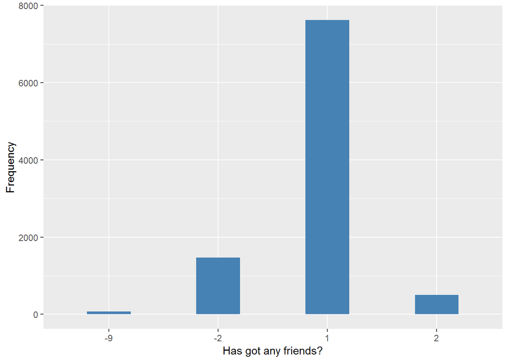

```
## $values_table
##               -9     -2     -1    1      2       3       4
## Frequency  90.00 1469.0 577.00 48.0 373.00 1357.00 5752.00
## Percentage  0.93   15.2   5.97  0.5   3.86   14.04   59.51
##
## $n_table
##      Sample size Missing values
## [1,]        9666              0
```

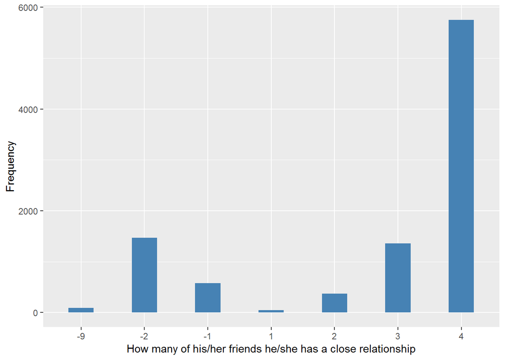

```
## $values_table
##                -9     -2     -1       1       2       3      4      5
## Frequency  146.00 1469.0 577.00 1060.00 3026.00 2079.00 906.00 276.00
## Percentage   1.51   15.2   5.97   10.97   31.31   21.51   9.37   2.86
##                 6
## Frequency  127.00
## Percentage   1.31
##
## $n_table
##      Sample size Missing values
## [1,]        9666              0
```

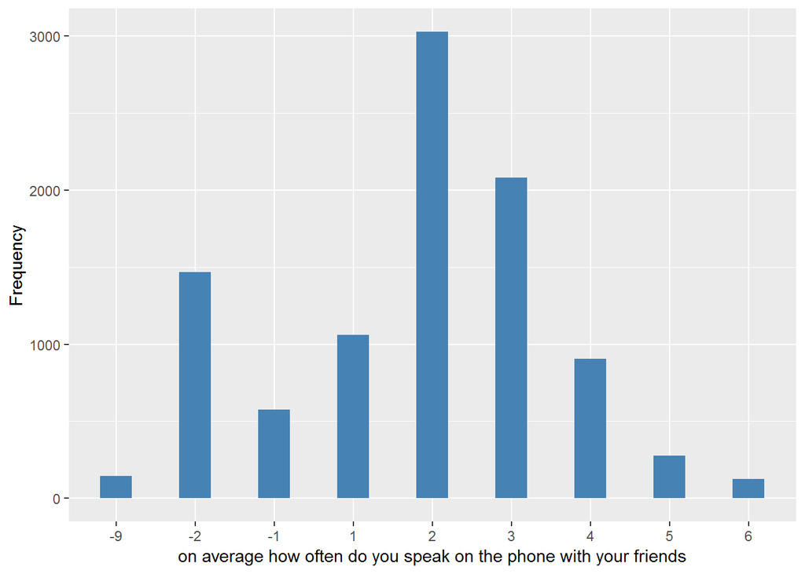

```
## $values_table
##                -9     -2     -1       1       2       3      4      5
## Frequency  182.00 1469.0 577.00 1065.00 2808.00 2212.00 850.00 256.00
## Percentage   1.88   15.2   5.97   11.02   29.05   22.88   8.79   2.65
##                 6
## Frequency  247.00
## Percentage   2.56
##
## $n_table
##      Sample size Missing values
## [1,]        9666              0
```

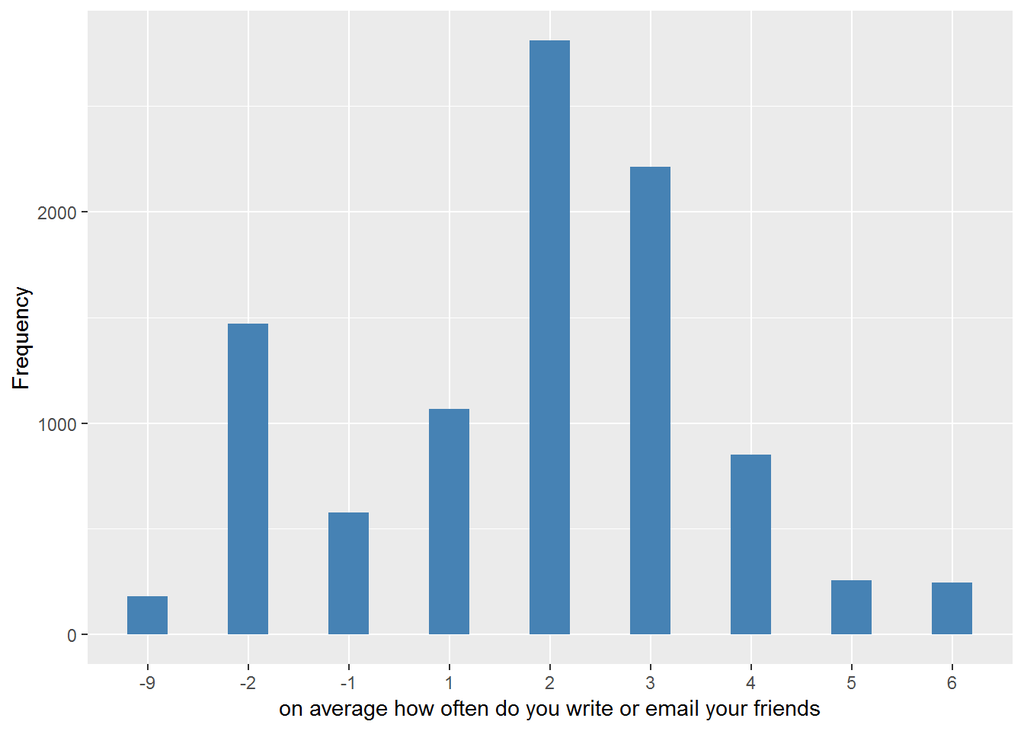

#### 2.1.7.2 Harmonisation algorithm

To recode the harmonize variable from the study-specific variable it has to be recoded as follows:

- `scfrdg in (1,2,3) OR scfrdh in (1,2,3) OR scfrdi in (1,2,3) into 1`
- `scfrdg in (4,5,6) AND scfrdh in (4,5,6) AND scfrdi in (4,5,6) into 0`
- `scfrd=2 into 0`
- `scfrdg = -9 OR scfrdh = -9 OR scfrdi = -9 into 995`
- `scfrdg = -8 OR scfrdh = -8 OR scfrdi = -8 into 998`
- `scfrdg in (-1, -2) OR scfrdh in (-1, -2) OR scfrdi in (-1, -2) into 996`
- `NA into 999`

**R script:**

```r
ELSA_ds_w7 <- tibble(id = ELSA_w7_cont_fr$id)

ELSA_w7_cont_fr$scfrd <- car::recode(as.vector(ELSA_w7_cont_fr$scfrd), "NA='-999'")
ELSA_w7_cont_fr$scfrdg <- car::recode(as.vector(ELSA_w7_cont_fr$scfrdg), "NA='-999'")
ELSA_w7_cont_fr$scfrdh <- car::recode(as.vector(ELSA_w7_cont_fr$scfrdh), "NA='-999'")
ELSA_w7_cont_fr$scfrdi <- car::recode(as.vector(ELSA_w7_cont_fr$scfrdi), "NA='-999'")

ELSA_ds_w7$cont_fr <- c(NA)
for (i in 1:dim(ELSA_w7_cont_fr)[1]) {
    if (ELSA_w7_cont_fr$scfrdg[i] %in% c(1, 2, 3) | ELSA_w7_cont_fr$scfrdh[i] %in%
        c(1, 2, 3) | ELSA_w7_cont_fr$scfrdi[i] %in% c(1, 2, 3)) {
        ELSA_ds_w7$cont_fr[i] = 1
    } else if (ELSA_w7_cont_fr$scfrdg[i] %in% c(4, 5, 6) & ELSA_w7_cont_fr$scfrdh[i] %in%
        c(4, 5, 6) & ELSA_w7_cont_fr$scfrdi[i] %in% c(4, 5, 6)) {
        ELSA_ds_w7$cont_fr[i] = 0
    } else if (ELSA_w7_cont_fr$scfrd[i] == 2) {
        ELSA_ds_w7$cont_fr[i] = 0
    } else if (ELSA_w7_cont_fr$scfrdg[i] == -9 | ELSA_w7_cont_fr$scfrdh[i] ==
        -9 | ELSA_w7_cont_fr$scfrdi[i] == -9) {
        ELSA_ds_w7$cont_fr[i] = 995
    } else if (ELSA_w7_cont_fr$scfrdg[i] == -8 | ELSA_w7_cont_fr$scfrdh[i] ==
        -8 | ELSA_w7_cont_fr$scfrdi[i] == -8) {
        ELSA_ds_w7$cont_fr[i] = 998
    } else if (ELSA_w7_cont_fr$scfrdg[i] %in% c(-1, -2) | ELSA_w7_cont_fr$scfrdh[i] %in%
        c(-1, -2) | ELSA_w7_cont_fr$scfrdi[i] %in% c(-1, -2)) {
        ELSA_ds_w7$cont_fr[i] = 996
    }
}

ELSA_ds_w7$cont_fr <- car::recode(as.vector(ELSA_ds_w7$cont_fr), "NA='999'")
ELSA_ds_w7$cont_fr <- labelled(ELSA_ds_w7$cont_fr, labels = c(No = 0, Yes = 1,
    Missing = 999, `Do not know` = 998, Refuse = 997, `Not applicable` = 996,
    `Don't answer` = 995, `Not attempt/not done/not yet recorded` = 994, `Disable to measure` = 993,
    Impute = 992, `CAPI/interviewer error` = 991, `NOT APPLICABLE - HAS NOT GOT ANY FRIENDS` = 990))
```

#### 2.1.7.3 Statistical description of the new harmonised variable

| Sample size | Missing values |
| --- | --- |
| 9666 | 1630 |

Category

|  | 0 | 1 |
| --- | --- | --- |
| Frequency | 1107.00 | 6929.00 |
| Percentage | 11.45 | 71.68 |

Type of missing

|  | 991 | 992 | 993 | 994 | 995 | 996 | 997 | 998 | 999 | NA |
| --- | --- | --- | --- | --- | --- | --- | --- | --- | --- | --- |
| Frequency | 0 | 0 | 0 | 0 | 88.00 | 1542.00 | 0 | 0 | 0 | 0 |
| Percentage | 0 | 0 | 0 | 0 | 0.91 | 15.95 | 0 | 0 | 0 | 0 |

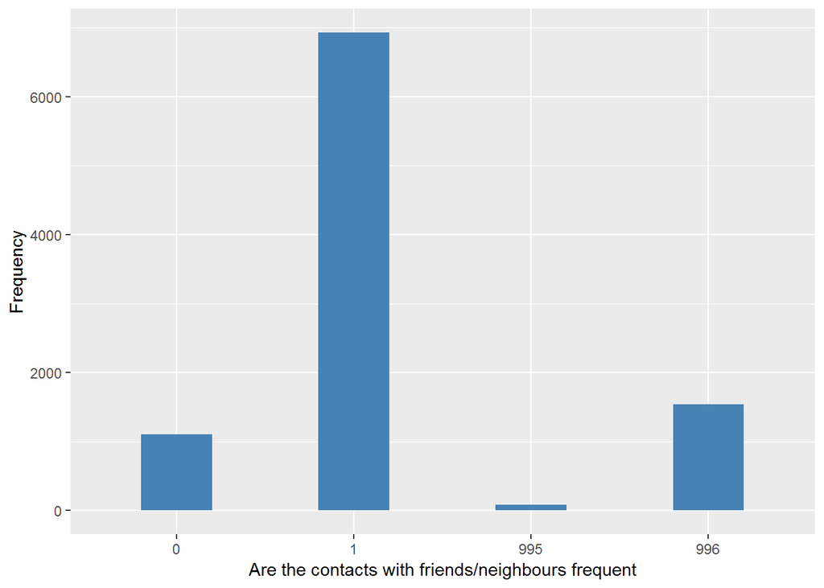

##### 2.1.7.3.1 Validation

# 3 Quality estimation